# Chevron Catalog

#### **5. Time-to-event Summary (modifying time point for the “survival at xx months” analysis)**

The time point for the “survival at xx months” analysis can be modified by specifying the argument `time_point`. By default, the function takes `AVAL` from `adtte` in days and converts it to months. The survival estimates are then summarized in month, and the numeric values should be provided in months to `time_point`.

```r
proc_data <- log_filter(syn_data, PARAMCD == "PFS", "adtte")

run(ttet01, proc_data, perform_analysis = "unstrat", time_point = c(3, 6))
```

```
#>                                        A: Drug X        B: Placebo      C: Combination
#>                                         (N=15)            (N=15)            (N=15)
#>   —————————————————————————————————————————————————————————————————————————————————————
#>   Patients with event (%)              7 (46.7%)         12 (80%)          8 (53.3%)
#>     Earliest contributing event
#>       Death                                5                11                 7
#>       Disease Progression                  2                 1                 1
#>   Patients without event (%)           8 (53.3%)          3 (20%)          7 (46.7%)
#>   Time to Event (MONTHS)
#>     Median                                8.6               6.2               8.4
#>       95% CI                           (7.3, NE)        (4.8, 7.6)         (7.0, NE)
#>     25% and 75%-ile                     3.8, NE          4.7, 8.4           5.8, NE
#>     Range                           1.2 to 9.5 {1}      0.9 to 9.1      0.9 to 9.5 {1}
#>   Unstratified Analysis
#>     p-value (log-rank)                                    0.0973            0.9111
#>     Hazard Ratio                                           2.18              1.06
#>     95% CI                                             (0.85, 5.60)      (0.38, 2.94)
#>   3 MONTHS
#>     Patients remaining at risk            12                12                13
#>     Event Free Rate (%)                  80.00             80.00             86.67
#>     95% CI                          (59.76, 100.00)   (59.76, 100.00)   (69.46, 100.00)
#>     Difference in Event Free Rate                          0.00              6.67
#>       95% CI                                          (-28.63, 28.63)   (-19.90, 33.23)
#>       p-value (Z-test)                                    1.0000            0.6228
#>   6 MONTHS
#>     Patients remaining at risk            11                 8                11
#>     Event Free Rate (%)                  73.33             53.33             73.33
#>     95% CI                          (50.95, 95.71)    (28.09, 78.58)    (50.95, 95.71)
#>     Difference in Event Free Rate                         -20.00             0.00
#>       95% CI                                          (-53.74, 13.74)   (-31.65, 31.65)
#>       p-value (Z-test)                                    0.2453            1.0000
#>   —————————————————————————————————————————————————————————————————————————————————————
#>
#>   {1} - Censored observation: range maximum
#>   —————————————————————————————————————————————————————————————————————————————————————
```

The following example shows how to specify the time point in **user-defined unit**.

```r
proc_data <- log_filter(syn_data, PARAMCD == "PFS", "adtte")

preprocess(ttet01) <- function(adam_db, dataset = "adtte",
                               ...) {
  adam_db[[dataset]] <- adam_db[[dataset]] %>%
    mutate(
      AVALU = "DAYS",
      IS_EVENT = .data$CNSR == 0,
      IS_NOT_EVENT = .data$CNSR == 1,
      EVNT1 = factor(
        case_when(
          IS_EVENT == TRUE ~ render_safe("{Patient_label} with event (%)"),
          IS_EVENT == FALSE ~ render_safe("{Patient_label} without event (%)")
        ),
        levels = render_safe(c("{Patient_label} with event (%)", "{Patient_label} without event (%)"))
      ),
      EVNTDESC = factor(.data$EVNTDESC)
    )

  adam_db
}

run(ttet01, proc_data, perform_analysis = "unstrat", time_point = c(91, 183))
```

```
#>                                         A: Drug X         B: Placebo       C: Combination
#>                                          (N=15)             (N=15)             (N=15)
#>   —————————————————————————————————————————————————————————————————————————————————————————
#>   Patients with event (%)               7 (46.7%)          12 (80%)           8 (53.3%)
#>     Earliest contributing event
#>       Death                                 5                 11                  7
#>       Disease Progression                   2                  1                  1
#>   Patients without event (%)            8 (53.3%)           3 (20%)           7 (46.7%)
#>   Time to Event (DAYS)
#>     Median                                261.9              187.7              256.3
#>       95% CI                           (221.9, NE)      (144.7, 232.2)       (212.0, NE)
#>     25% and 75%-ile                     114.9, NE        141.9, 254.4         175.0, NE
#>     Range                           37.2 to 288.3 {1}    28.0 to 276.6    26.4 to 288.1 {1}
#>   Unstratified Analysis
#>     p-value (log-rank)                                      0.0973             0.9111
#>     Hazard Ratio                                             2.18               1.06
#>     95% CI                                               (0.85, 5.60)       (0.38, 2.94)
#>   91 DAYS
#>     Patients remaining at risk             12                 12                 13
#>     Event Free Rate (%)                   80.00              80.00              86.67
#>     95% CI                           (59.76, 100.00)    (59.76, 100.00)    (69.46, 100.00)
#>     Difference in Event Free Rate                            0.00               6.67
#>       95% CI                                            (-28.63, 28.63)    (-19.90, 33.23)
#>       p-value (Z-test)                                      1.0000             0.6228
#>   183 DAYS
#>     Patients remaining at risk             11                  8                 11
#>     Event Free Rate (%)                   73.33              53.33              73.33
#>     95% CI                           (50.95, 95.71)     (28.09, 78.58)     (50.95, 95.71)
#>     Difference in Event Free Rate                           -20.00              0.00
#>       95% CI                                            (-53.74, 13.74)    (-31.65, 31.65)
#>       p-value (Z-test)                                      0.2453             1.0000
#>   —————————————————————————————————————————————————————————————————————————————————————————
#>
#>   {1} - Censored observation: range maximum
#>   —————————————————————————————————————————————————————————————————————————————————————————
```

#### **6. Time-to-event Summary (modifying the p-value method for testing hazard ratio)**

The default p-value method for testing hazard ratio is “log-rank”. Alternative methods can be requested by specifying the argument `pval_method` and options include, `log-rank` (default), `wald` or `likelihood`. The syntax currently does not allow requesting more than one p-value.

Note that `ttet01` has been modified in the previous example (i.e., `preprocess(ttet01)` has been overridden); to access the default template, try `chevron::ttet01`.

```r
proc_data <- log_filter(syn_data, PARAMCD == "PFS", "adtte")

run(ttet01, proc_data, pval_method = "wald")
```

```
#>                                       A: Drug X          B: Placebo       C: Combination
#>                                        (N=15)              (N=15)             (N=15)
#>   ————————————————————————————————————————————————————————————————————————————————————————
#>   Patients with event (%)             7 (46.7%)           12 (80%)           8 (53.3%)
#>     Earliest contributing event
#>       Death                               5                  11                  7
#>       Disease Progression                 2                  1                   1
#>   Patients without event (%)          8 (53.3%)           3 (20%)            7 (46.7%)
#>   Time to Event (DAYS)
#>     Median                              261.9              187.7               256.3
#>       95% CI                         (221.9, NE)       (144.7, 232.2)       (212.0, NE)
#>     25% and 75%-ile                   114.9, NE         141.9, 254.4         175.0, NE
#>     Range                         37.2 to 288.3 {1}    28.0 to 276.6     26.4 to 288.1 {1}
#>   Unstratified Analysis
#>     p-value (wald)                                         0.1053             0.9111
#>     Hazard Ratio                                            2.18               1.06
#>     95% CI                                              (0.85, 5.60)       (0.38, 2.94)
#>   6 DAYS
#>     Patients remaining at risk           15                  15                 15
#>     Event Free Rate (%)                100.00              100.00             100.00
#>     95% CI                        (100.00, 100.00)    (100.00, 100.00)   (100.00, 100.00)
#>   12 DAYS
#>     Patients remaining at risk           15                  15                 15
#>     Event Free Rate (%)                100.00              100.00             100.00
#>     95% CI                        (100.00, 100.00)    (100.00, 100.00)   (100.00, 100.00)
#>   ————————————————————————————————————————————————————————————————————————————————————————
#>
#>   {1} - Censored observation: range maximum
#>   ————————————————————————————————————————————————————————————————————————————————————————
```

### **Vital Signs (`VST01`)**

#### **1. Vital Sign Results and Change from Baseline by Visit**

```r
t_vs_chg <- run(vst01, syn_data)
head(t_vs_chg, 20)
```

```
#>                                        A: Drug X                      B: Placebo                    C: Combination
#>                                               Change from                     Change from                     Change from
#>                              Value at Visit     Baseline     Value at Visit     Baseline     Value at Visit     Baseline
#>                                  (N=15)          (N=15)          (N=15)          (N=15)          (N=15)          (N=15)
#>   ————————————————————————————————————————————————————————————————————————————————————————————————————————————————————————
#>   Diastolic Blood Pressure
#>     SCREENING
#>       n                            15              0               15              0               15              0
#>       Mean (SD)               94.4 (17.1)       NE (NE)       106.4 (20.6)      NE (NE)       106.5 (12.6)      NE (NE)
#>       Median                      94.9             NE            111.1             NE            108.4             NE
#>       Min - Max                 56 - 122        NE - NE         60 - 132        NE - NE         83 - 127        NE - NE
#>     BASELINE
#>       n                            15                              15                              15
#>       Mean (SD)               96.1 (22.5)                     108.1 (15.1)                    103.1 (19.8)
#>       Median                      93.3                           109.0                           102.8
#>       Min - Max                 61 - 137                        83 - 132                        66 - 137
#>     WEEK 1 DAY 8
#>       n                            15              15              15              15              15              15
#>       Mean (SD)               99.0 (21.4)      2.8 (28.1)     104.1 (16.2)    -4.0 (21.9)     100.8 (19.0)    -2.3 (25.0)
#>       Median                      92.4            -4.1           107.7            3.2            103.1            -2.5
#>       Min - Max                 68 - 130        -33 - 48        71 - 133        -53 - 29        70 - 129        -55 - 42
#>     WEEK 2 DAY 15
#>       n                            15              15              15              15              15              15
#>       Mean (SD)               99.8 (14.5)      3.6 (21.2)     97.5 (17.3)     -10.6 (20.8)    94.3 (17.0)     -8.9 (27.2)
#>       Median                     101.5            1.7             99.5            -9.7            96.8           -10.2
```

### **Vital Signs Abnormalities (Regardless of Abnormality at Baseline) (`VST02_1`)**

#### **1. Vital Sign Abnormalities (Regardless of Abnormality at Baseline)**

```r
run(vst02_1, syn_data)
```

```
#>   Assessment                   A: Drug X      B: Placebo     C: Combination
#>    Abnormality                  (N=15)          (N=15)           (N=15)
#>   —————————————————————————————————————————————————————————————————————————
#>   Diastolic Blood Pressure
#>     Low                      8/15 (53.3%)     9/15 (60%)      8/15 (53.3%)
#>     High                     10/15 (66.7%)   5/15 (33.3%)     8/15 (53.3%)
#>   Pulse Rate
#>     Low                       9/15 (60%)      3/15 (20%)      5/15 (33.3%)
#>     High                     2/15 (13.3%)     6/15 (40%)      5/15 (33.3%)
#>   Respiratory Rate
#>     Low                      13/15 (86.7%)   10/15 (66.7%)   13/15 (86.7%)
#>     High                     7/15 (46.7%)    10/15 (66.7%)   11/15 (73.3%)
#>   Systolic Blood Pressure
#>     Low                      7/15 (46.7%)     9/15 (60%)     11/15 (73.3%)
#>     High                     10/15 (66.7%)    9/15 (60%)       9/15 (60%)
#>   Temperature
#>     Low                       12/15 (80%)    13/15 (86.7%)   11/15 (73.3%)
#>     High                     14/15 (93.3%)    12/15 (80%)    14/15 (93.3%)
#>   Weight
#>     Low                       3/15 (20%)      3/15 (20%)      4/15 (26.7%)
#>     High                     4/15 (26.7%)    4/15 (26.7%)     5/15 (33.3%)
```

### **Vital Signs Abnormalities (Among Subject Without Abnormality at Baseline) (`VST02_2`)**

#### **1. Vital Sign Abnormalities (Among Subject Without Abnormality at Baseline)**

```r
run(vst02_2, syn_data)
```

```
#>   Assessment                  A: Drug X      B: Placebo    C: Combination
#>    Abnormality                  (N=15)         (N=15)          (N=15)
#>   ———————————————————————————————————————————————————————————————————————
#>   Diastolic Blood Pressure
#>     Low                      6/11 (54.5%)    9/15 (60%)      6/12 (50%)
#>     High                     8/12 (66.7%)   4/11 (36.4%)    7/13 (53.8%)
#>   Pulse Rate
#>     Low                       9/15 (60%)     3/15 (20%)     5/13 (38.5%)
#>     High                     2/14 (14.3%)   4/12 (33.3%)    5/15 (33.3%)
#>   Respiratory Rate
#>     Low                      7/9 (77.8%)    7/11 (63.6%)   11/12 (91.7%)
#>     High                     6/14 (42.9%)   7/11 (63.6%)    9/13 (69.2%)
#>   Systolic Blood Pressure
#>     Low                      5/13 (38.5%)   8/12 (66.7%)   10/14 (71.4%)
#>     High                     8/13 (61.5%)   8/13 (61.5%)    8/13 (61.5%)
#>   Temperature
#>     Low                       8/10 (80%)    7/9 (77.8%)      8/10 (80%)
#>     High                      8/8 (100%)    7/8 (87.5%)    12/13 (92.3%)
#>   Weight
#>     Low                       3/15 (20%)     3/15 (20%)     3/14 (21.4%)
#>     High                     4/14 (28.6%)   4/15 (26.7%)    5/14 (35.7%)
```

## **LISTINGS**

### **Glossary of Adverse Event Preferred Terms and Investigator-Specified Terms (`AEL01_NOLLT`)**

#### **1. Glossary of Adverse Event Preferred Terms and Investigator-Specified Terms**

1. The **`ael01_nollt`** template produces the standard glossary of adverse event preferred terms and investigator-specified terms.
2. The example below uses `head` function to print only the first 10 lines of the output.

```r
l_ae_nollt <- run(ael01_nollt, syn_data)
head(l_ae_nollt, 10)
```

```
#> MedDRA System Organ Class   MedDRA Preferred Term   Reported Term for the Adverse Event
#> ———————————————————————————————————————————————————————————————————————————————————————
#> cl A.1                      dcd A.1.1.1.1           trm A.1.1.1.1
#>                             dcd A.1.1.1.2           trm A.1.1.1.2
#> cl B.1                      dcd B.1.1.1.1           trm B.1.1.1.1
#> cl B.2                      dcd B.2.1.2.1           trm B.2.1.2.1
#>                             dcd B.2.2.3.1           trm B.2.2.3.1
#> cl C.1                      dcd C.1.1.1.3           trm C.1.1.1.3
#> cl C.2                      dcd C.2.1.2.1           trm C.2.1.2.1
#> cl D.1                      dcd D.1.1.1.1           trm D.1.1.1.1
#>                             dcd D.1.1.4.2           trm D.1.1.4.2
#> cl D.2                      dcd D.2.1.5.3           trm D.2.1.5.3
```

## **Graphics**

### **Forest Plot for Odds Ratio (`FSTG01`)**

#### **1. Forest Plot for Odds Ratio (with subgroup analysis)**

1. The **`fstg01`** template produces the standard forest plot for odds ratio.
2. Users are expected to subset the parameter of interest (e.g. `PARAMCD == "BESRSPI"`) in pre-processing.
3. Users are expected to subset the arm variable to keep only the two arms to compare (e.g. `ARM %in% c("A: Drug X", "B: Placebo")`).
4. By default, the plots displays a subgroup analysis for `"SEX"`, `"AGEGR1"` and `"RACE"`.
5. Unstratified analysis is provided by default.
6. The plots displays by default the Total number of subjects, the odd ratio and the 95% confidence interval, and, for each arm, the number of subject, the number of responders and the proportion of responders.

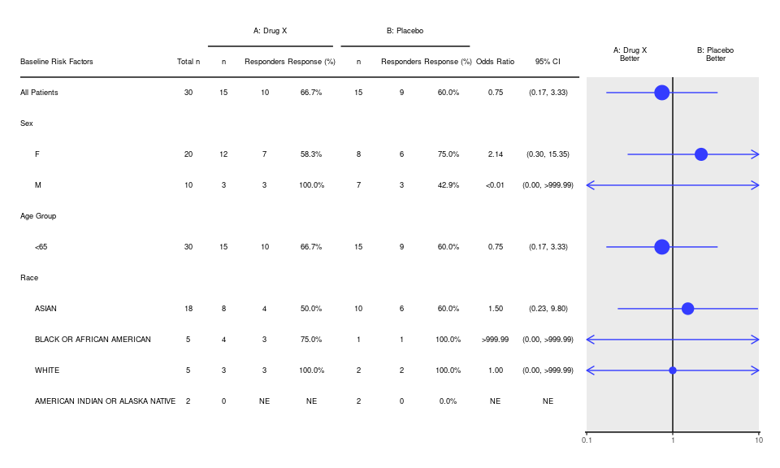

```r
proc_data <- log_filter(
  syn_data,
  PARAMCD == "BESRSPI" & ARM %in% c("A: Drug X", "B: Placebo"), "adrs"
)
run(fstg01, proc_data)
```

#### **2. Forest Plot for Odds Ratio (with a user-defined confidence level)**

The confidence level of the confidence interval can be adjusted by the `conf_level` argument.

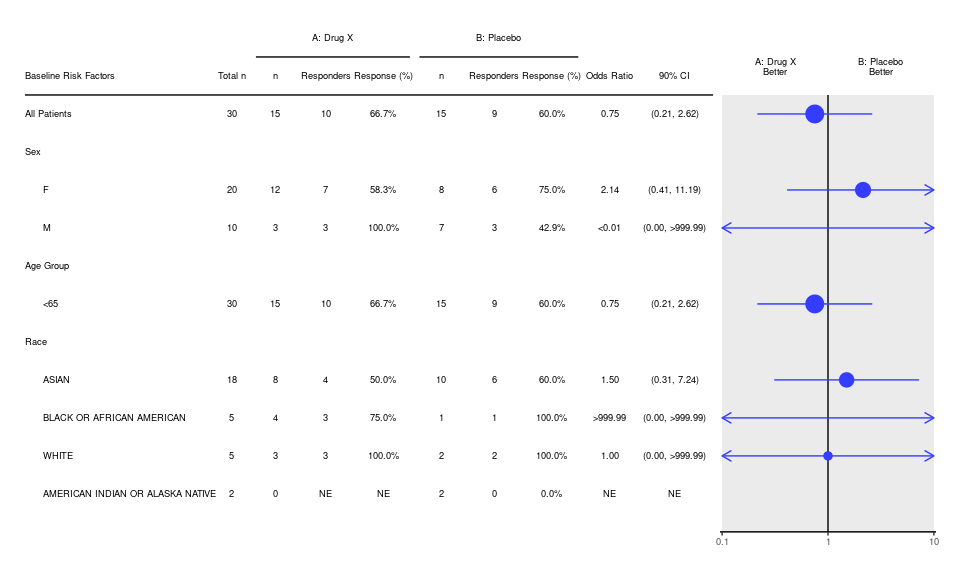

```r
run(fstg01, proc_data, conf_level = 0.90)
```

#### **3. Forest Plot for Odds Ratio (with p-values and/or different statistics)**

The interaction p-values and a different set of statistics can be displayed using the `stat_var` argument. Note that the users are expected to select a method for p-value computation. see `[tern::prop_diff_test]`.

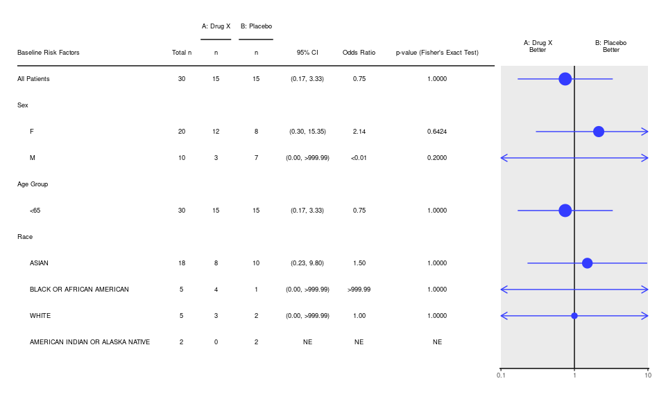

```r
run(fstg01, proc_data, method = "fisher", stat_var = c("n_tot", "n", "ci", "or", "pval"))
```

#### **4. Forest Plot for Odds Ratio (with user-defined subgroup analysis)**

The `subgroups` arguments controls which variables are used for subgroup analysis. If `NULL`the subgroup analysis is removed.

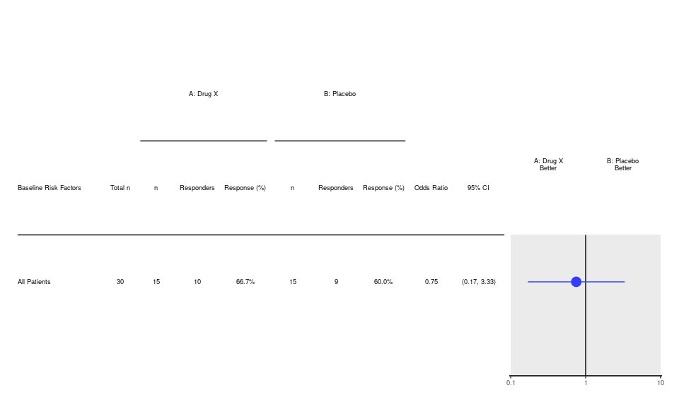

```r
run(fstg01, proc_data, subgroups = NULL)
```

#### **5. Forest Plot for Odds Ratio (with stratified analysis)**

The `strata_var` argument is used to pass the columns used for stratified analysis.

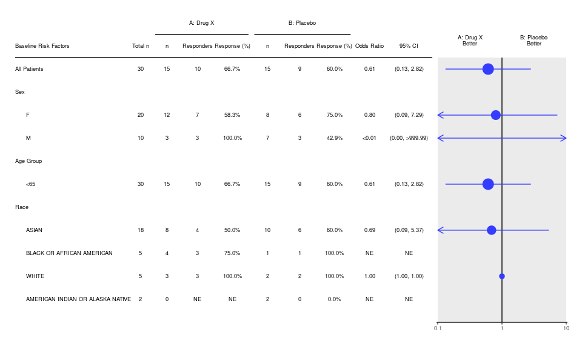

```r
run(fstg01, proc_data, strata_var = "STRATA1")
```

#### **6. Forest Plot for Odds Ratio (without proportional sizing of the odds ratio symbol)**

The `col_symbol_size` argument controls the size of the odds ratio symbols which are by default proportional in size to the sample size of the subgroup. If `NULL` the same symbol size is used for all subgroups.

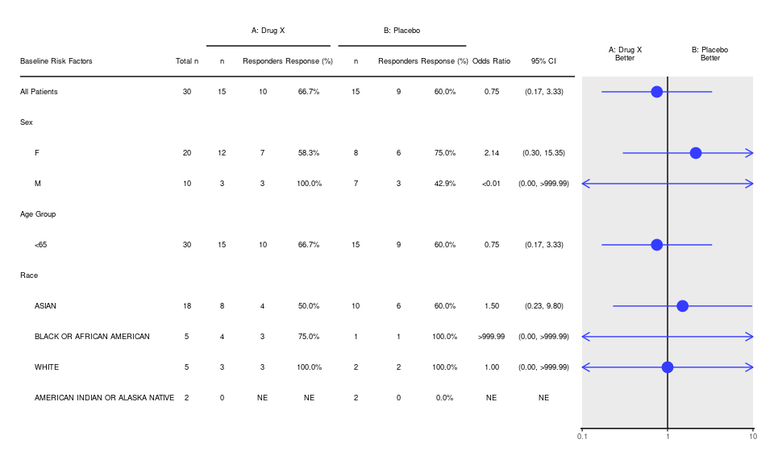

```r
run(fstg01, proc_data, col_symbol_size = NULL)
```

### **Forest Plot for Hazard Ratio (`FSTG02`)**

#### **1. Forest Plot for Hazard Ratio (with subgroup analysis)**

1. The **`fstg02`** template produces the standard forest plot for hazard ratio.
2. Users are expected to subset the parameter of interest (e.g. `PARAMCD == "OS"`) in pre-processing.
3. Users are expected to subset the arm variable to keep only the two arms to compare (e.g. `ARM %in% c("A: Drug X", "B: Placebo")`).
4. By default, the plots displays a subgroup analysis for `"SEX"`, `"AGEGR1"` and `"RACE"`.
5. Unstratified analysis is provided by default.
6. The plots displays by default the Total number of events, the hazard ratio and the 95% confidence interval, and, for each arm, the number of events and the median time to event in month.

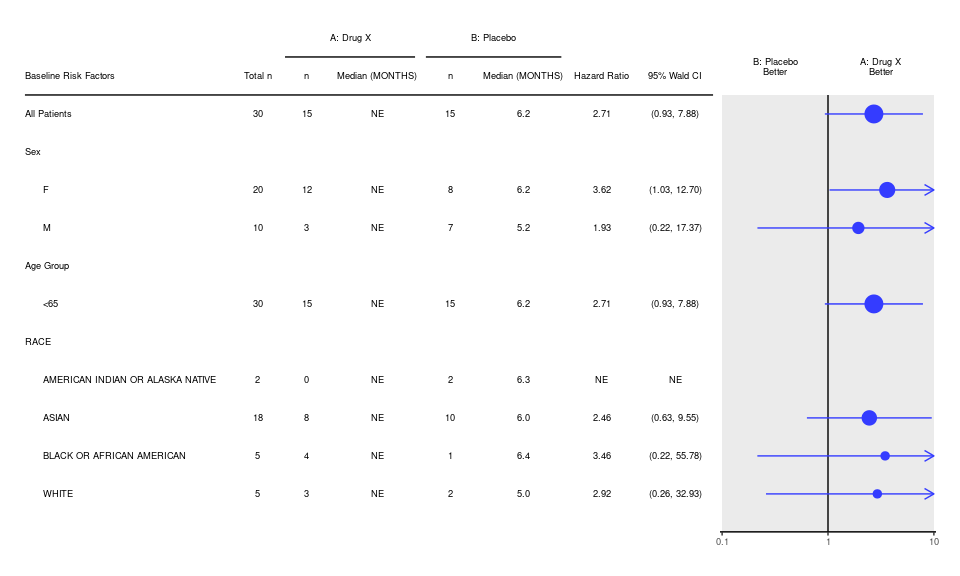

```r
proc_data <- log_filter(
  syn_data,
  PARAMCD == "OS" & ARM %in% c("A: Drug X", "B: Placebo"), "adtte"
)
run(fstg02, proc_data)
```

#### **2. Forest Plot for Hazard Ratio (with p-values and/or different statistics)**

The interaction p-values and a different set of statistics can be displayed using the `control` argument. More details about the control options are available in `[tern::extract_survival_subgroups]`

```r
run(
  fstg02,
  proc_data,
  stat_var = c("n_tot", "n", "ci", "hr", "pval"),
  control = tern::control_coxph(conf_level = 0.9, pval_method = "likelihood")
)
```

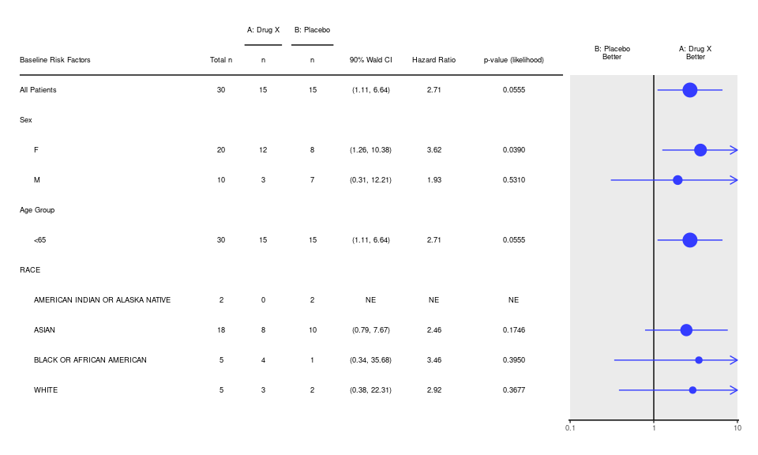

#### **3. Forest Plot for Hazard Ratio (with user-defined subgroup analysis)**

The `subgroups` arguments controls which variables are used for subgroup analysis. If `NULL`the subgroup analysis is removed.

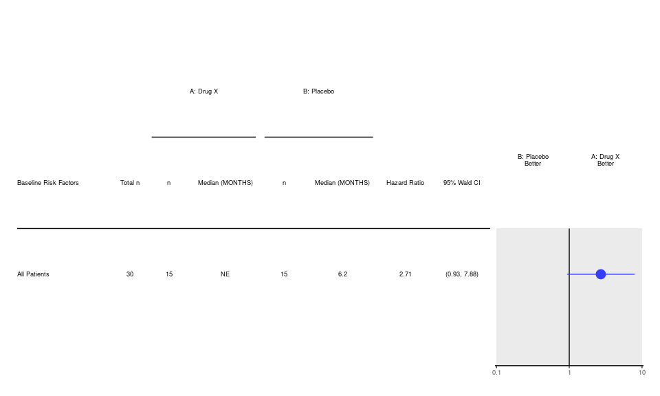

```r
run(fstg02, proc_data, subgroups = NULL)
```

#### **4. Forest Plot for Hazard Ratio (with stratified analysis)**

The `strata_var` argument is used to pass the columns used for stratified analysis.

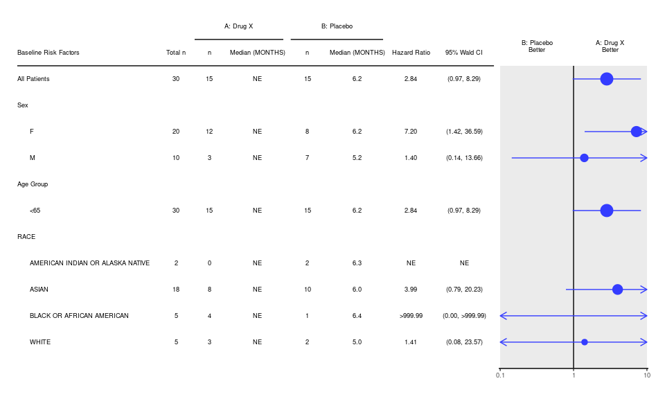

```r
run(fstg02, proc_data, strata_var = "STRATA1")
```

#### **5. Forest Plot for Hazard Ratio (without proportional sizing of the hazard ratio symbol)**

The `col_symbol_size` argument controls the size of the hazard ratio symbols which are by default proportional in size to the number of events in the subgroup. If `NULL` the same symbol size is used for all subgroups.

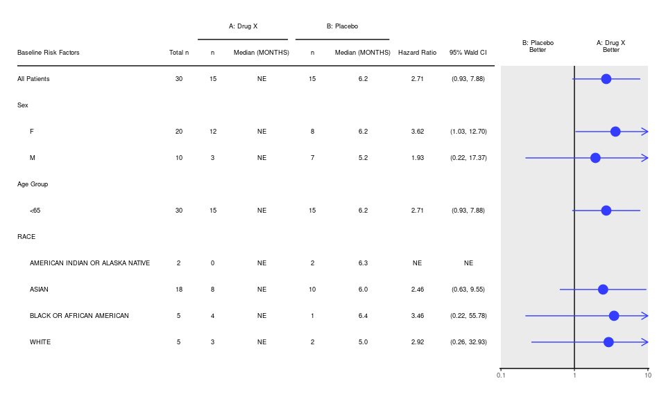

```r
run(fstg02, proc_data, col_symbol_size = NULL)
```

### **Kaplan-Meier Plot (`KMG01`)**

#### **1. Kaplan-Meier Plot (without comparative statistics)**

1. The **`kmg01`** template produces the standard Kaplan-Meier Plot.
2. Users are expected to select a particular parameter for analysis.
3. Users are expected to select the treatment groups to compare, otherwise, all treatment groups available in the input datasets will be plotted.
4. The comparative statistics are not included by default.
5. The estimation of median survival time per treatment group by default.
6. More arguments in the `g_km` and `control_coxph` functions can be passed through, please use the Help to find out more information.

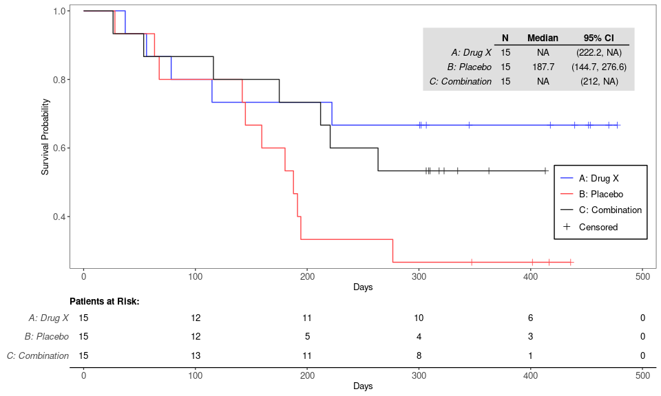

```r
proc_data <- log_filter(syn_data, PARAMCD == "OS", "adtte")
run(kmg01, proc_data, dataset = "adtte")
```

#### **2. Kaplan-Meier Plot (with comparative statistics)**

To enable the comparative statistics (hazard ratio and p-value), the argument `annot_coxph` needs to be set to TRUE. The compare group is determined by the levels in the factorized variable of treatment group and the first level is used as reference group in the statistics.

```r
proc_data <- log_filter(syn_data, PARAMCD == "OS", "adtte")
run(
  kmg01,
  proc_data,
  dataset = "adtte",
  annot_coxph = TRUE,
  control_annot_coxph = tern::control_coxph_annot(x = 0.33, y = 0.42)
)
```

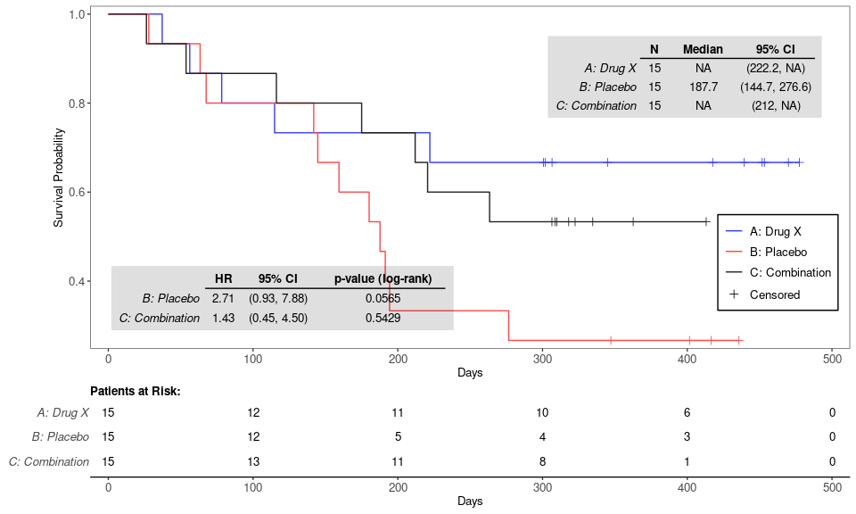

#### **3. Kaplan-Meier Plot (without censoring marks)**

To suppress the censoring marks, set the argument `cencor_show` to FALSE.

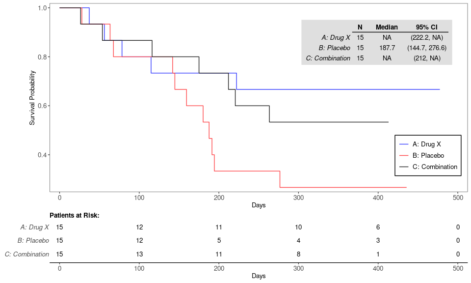

```r
proc_data <- log_filter(syn_data, PARAMCD == "OS", "adtte")
run(kmg01, proc_data, dataset = "adtte", censor_show = FALSE)
```

#### **4. Kaplan-Meier Plot (without estimation of median survival time)**

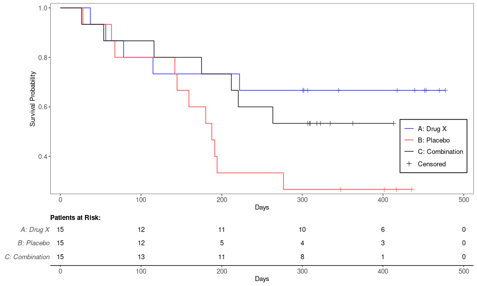

```r
proc_data <- log_filter(syn_data, PARAMCD == "OS", "adtte")
run(kmg01, proc_data, dataset = "adtte", annot_surv_med = FALSE)
```

#### **5. Kaplan-Meier Plot (with statistical annotation of either median or min of survival time)**

To add the statistics annotation, use the function `annot_stats`. Options are `min` or `median`.

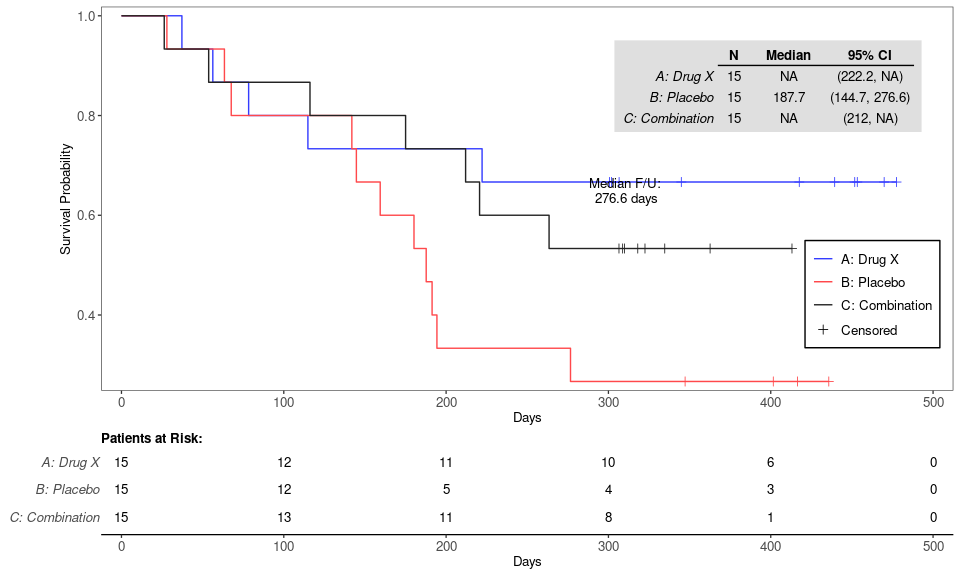

```r
proc_data <- log_filter(syn_data, PARAMCD == "OS", "adtte")
run(kmg01, proc_data, dataset = "adtte", annot_stats = "median")
```

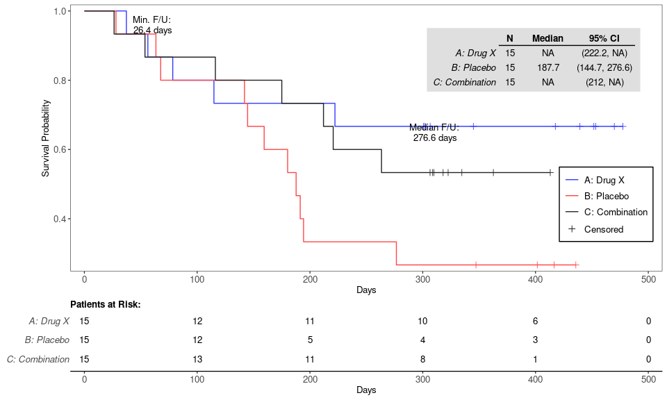

```r
run(kmg01, proc_data, dataset = "adtte", annot_stats = c("min", "median"))
```

#### **6. Kaplan-Meier Plot (without the table of patients at risk)**

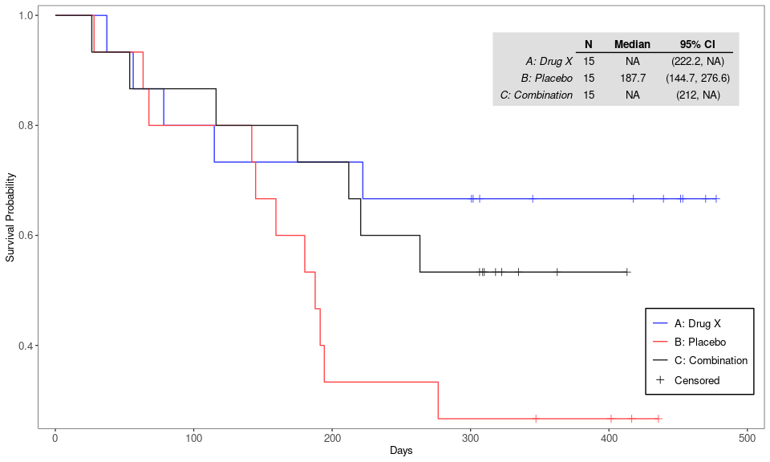

```r
proc_data <- log_filter(syn_data, PARAMCD == "OS", "adtte")
run(kmg01, proc_data, dataset = "adtte", annot_at_risk = FALSE)
```

### **Mean Plot (`MNG01`)**

#### **1. Plot of Mean and Confidence Interval (with Table Section)**

1. The **`mng01`** template produces the standard mean plot.
2. Note that the template `mng01` is quite general. The users are expected to specify the analysis dataset and the visit variable in the `run` function, and select the parameters prior to the `run` function.
3. The table of summary statistics is included by default.
4. The variable Analysis Value `AVAL` is used for plotting by default.
5. If the input dataset contains results of the same analyses in multiple units,(e.g. SI/CV units in `ADLB`), please make sure that the parameters in appropriate units are selected in advance.

```r
proc_data <- log_filter(syn_data, PARAMCD == "DIABP", "advs")
run(mng01, proc_data, dataset = "advs", x_var = c("AVISIT", "AVISITN"))
```

```
#> $`Diastolic Blood Pressure`
```

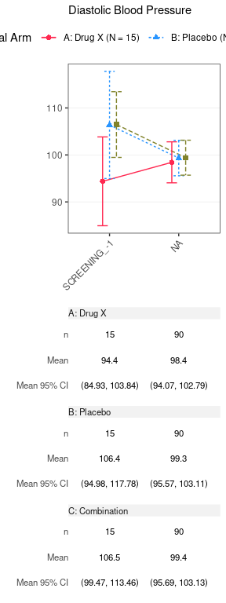

#### **2. Plot of Mean and Confidence Interval of Change from Baseline of Vital Signs**

```r
proc_data <- log_filter(syn_data, PARAMCD == "DIABP", "advs")
run(mng01, proc_data, dataset = "advs", x_var = c("AVISIT", "AVISITN"), y_var = "CHG")
```

```
#> `geom_line()`: Each group consists of only one observation.
#> ℹ Do you need to adjust the group aesthetic?
#> $`Diastolic Blood Pressure`
```

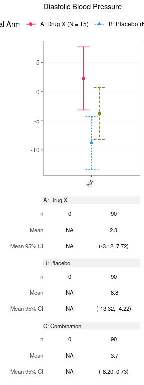

#### **3. Plot of Mean (+/-SD) (Changing the Statistics)**

To change the statistics, use the argument `interval_fun`. Options are `mean_ci`, `mean_sei`, `mean_sdi`, `median_ci`, `quantiles`,`range`.

```r
proc_data <- log_filter(syn_data, PARAMCD == "DIABP", "advs")
run(mng01, proc_data, dataset = "advs", x_var = c("AVISIT", "AVISITN"), interval_fun = "mean_sdi")
```

```
#> $`Diastolic Blood Pressure`
```

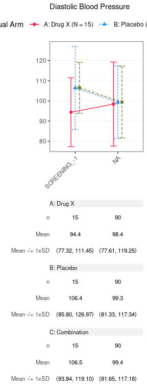

#### **4. Plot of Mean and Confidence Interval (Modify Alpha Level)**

To change the alpha level of the confidence interval, use the argument `control = control_analyze_vars(conf_level = <0.xx>)`. Note that this is only in effect when `interval_fun` is set to `mean_ci`.

```r
proc_data <- log_filter(syn_data, PARAMCD == "DIABP", "advs")
run(
  mng01, proc_data,
  dataset = "advs", x_var = c("AVISIT", "AVISITN"),
  interval_fun = "mean_ci", control = tern::control_analyze_vars(conf_level = 0.80)
)
```

```
#> $`Diastolic Blood Pressure`
```

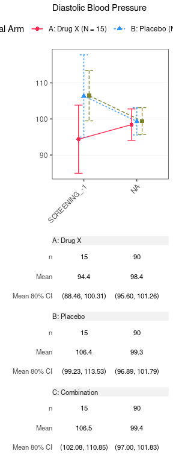

#### **5. Plot of Mean and Confidence Interval （With Number of Patients Only)**

```r
proc_data <- log_filter(syn_data, PARAMCD == "DIABP", "advs")
run(mng01, proc_data, dataset = "advs", x_var = c("AVISIT", "AVISITN"), table = "n")
```

```
#> $`Diastolic Blood Pressure`
```

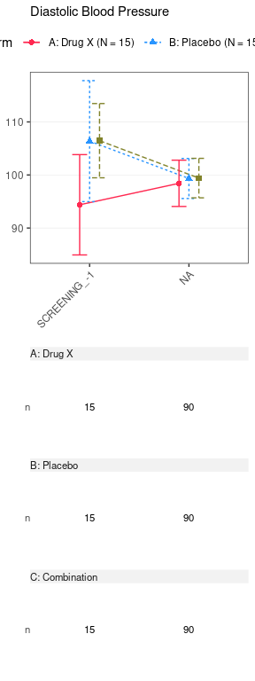

#### **6. Plot of Mean and Confidence Interval (without Table Section)**

```r
proc_data <- log_filter(syn_data, PARAMCD == "DIABP", "advs")
run(mng01, proc_data, dataset = "advs", x_var = c("AVISIT", "AVISITN"), table = NULL)
```

```
#> $`Diastolic Blood Pressure`
```

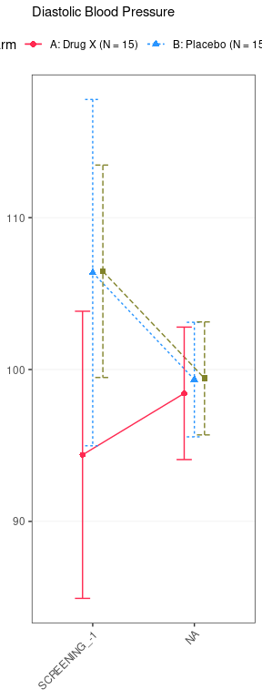

A new argument has been added to control the theme (e.g. setting the angle of the axis); see an example below:

```
#> $`Alanine Aminotransferase Measurement`
```

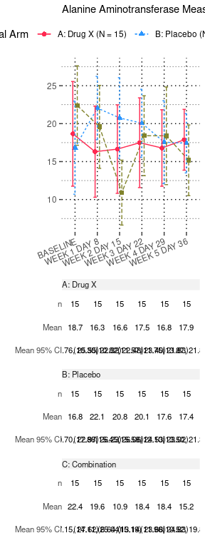

```
#>
#> $`C-Reactive Protein Measurement`
```

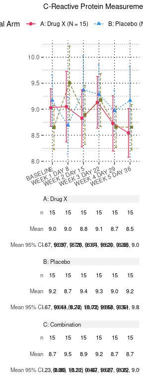

```
#>
#> $`Immunoglobulin A Measurement`
```

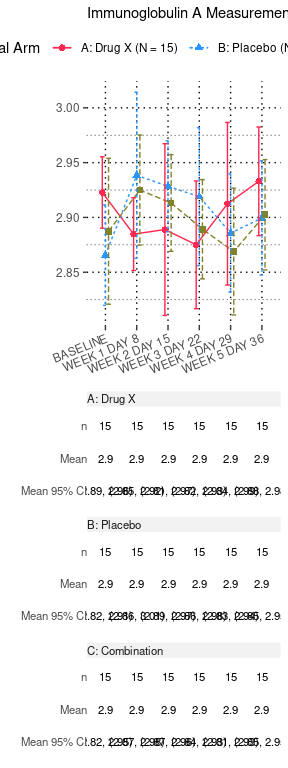

```r
ggtheme <- ggplot2::theme(
  panel.grid = ggplot2::element_line(colour = "black", linetype = 3),
  panel.background = ggplot2::element_rect(fill = "white"),
  legend.position = "top",
  axis.text.x = ggplot2::element_text(angle = 22, hjust = 1, vjust = 1)
)
run(mng01, syn_data, dataset = "adlb", ggtheme = ggtheme)
```